# Analyzing the Most Important Basic Statistic in Winning NBA Basketball Games

### Praneeth Malyala

[figure not shown]

In basketball, there are many statistics in the game like points, rebounds, assists, steals, and more that are kept track of. Generally, for each stat, the more each team has, the better. But I want to investigate which of those statistics (not including points obviously) is most conducive to a team winning.

In theory, arguments could be made for the importance of each of those statistics. For instance, rebounds are vital because a defensive rebounding prevents the opposing team from having a 2nd opportunity to score, and an offensive rebound gives the team another opportunity to score, both of which help the team win. Assists are essential because they indicate that the team has good ball movement, which is vital for a team's offense. Steals are imperative because they prevent the opposing team from scoring on that play and oftentimes will give the team an advantageous position to score. Blocks are key because they occur mostly in the paint, stopping the opposing team's easier shots from being scored. As you can see, there is a reasoning for the importance of each statistic for a team winning, but I wish to find out which one statistic is the most critical in leading to a team's win in the NBA. With the help of data science, I hope to find out the answer.

### Data Collection

To find the most important statistic, I am going to analyze the box scores of NBA regular-season games. To get the data, I downloaded the sqlite file from https://www.kaggle.com/datasets/wyattowalsh/basketball?resource=download, which has box scores from 1946 (when the NBA started) to 2021. From there, I queried the necessary columns from the "GAME" table.

I will first start by creating a pandas dataframe of the box scores

```python
import sqlite3
import pandas as pd
import statsmodels.api as sm
from sklearn.preprocessing import OrdinalEncoder
import seaborn as sns
import matplotlib.pyplot as plt
import numpy as np
from scipy import stats

sqlite_file = 'basketball.sqlite'
conn = sqlite3.connect(sqlite_file)
cur = conn.cursor()

games_query = "SELECT GAME_DATE, WL_HOME, OREB_HOME, DREB_HOME, REB_HOME, AST_HOME, STL_HOME, BLK_HOME, TOV_HOME, PF_HOME, PTS_HOME, TEAM_NAME_AWAY, WL_AWAY, OREB_AWAY, DREB_AWAY, REB_AWAY, AST_AWAY, STL_AWAY, BLK_AWAY, TOV_AWAY, PF_AWAY, PTS_AWAY FROM GAME"
total_games = pd.read_sql(games_query, conn)
```

```python
total_games
```

|  | GAME_DATE | WL_HOME | OREB_HOME | DREB_HOME | REB_HOME | AST_HOME | STL_HOME | BLK_HOME | TOV_HOME | PF_HOME | ... | WL_AWAY | OREB_AWAY | DREB_AWAY | REB_AWAY | AST_AWAY | STL_AWAY | BLK_AWAY | TOV_AWAY | PF_AWAY | PTS_AWAY |
| --- | --- | --- | --- | --- | --- | --- | --- | --- | --- | --- | --- | --- | --- | --- | --- | --- | --- | --- | --- | --- | --- |
| 0 | 1946-11-01 | L | None | None | None | None | None | None | None | NaN | ... | W | None | None | None | None | None | None | None | NaN | 68 |
| 1 | 1946-11-02 | W | None | None | None | None | None | None | None | 21.0 | ... | L | None | None | None | None | None | None | None | 25.0 | 51 |
| 2 | 1946-11-02 | W | None | None | None | None | None | None | None | 20.0 | ... | L | None | None | None | None | None | None | None | 22.0 | 47 |
| 3 | 1946-11-02 | W | None | None | None | None | None | None | None | NaN | ... | L | None | None | None | None | None | None | None | NaN | 53 |
| 4 | 1946-11-02 | L | None | None | None | None | None | None | None | NaN | ... | W | None | None | None | None | None | None | None | NaN | 50 |
| ... | ... | ... | ... | ... | ... | ... | ... | ... | ... | ... | ... | ... | ... | ... | ... | ... | ... | ... | ... | ... | ... |
| 62443 | 2021-05-16 | W | 11 | 40 | 51 | 24 | 3 | 6 | 14 | 16.0 | ... | L | 10 | 26 | 36 | 20 | 8 | 2 | 6 | 20.0 | 116 |
| 62444 | 2021-05-16 | W | 11 | 27 | 38 | 35 | 11 | 4 | 10 | 22.0 | ... | L | 11 | 27 | 38 | 32 | 5 | 5 | 16 | 19.0 | 121 |
| 62445 | 2021-05-16 | W | 8 | 37 | 45 | 23 | 8 | 8 | 16 | 20.0 | ... | L | 10 | 31 | 41 | 14 | 13 | 5 | 12 | 16.0 | 112 |
| 62446 | 2021-05-16 | L | 8 | 39 | 47 | 26 | 4 | 5 | 21 | 18.0 | ... | W | 8 | 34 | 42 | 30 | 14 | 5 | 10 | 16.0 | 110 |
| 62447 | 2021-05-16 | L | 5 | 34 | 39 | 24 | 10 | 5 | 13 | 22.0 | ... | W | 9 | 41 | 50 | 28 | 9 | 3 | 16 | 14.0 | 121 |

62448 rows × 22 columns

Now that I have all the box scores, I want to limit the NBA games to the range from 2001 to 2021. While this may seem counterintuitive as I am getting rid of thousands of observations, the reason is that the game of basketball has changed significantly since the NBA's inception, and to best analyze NBA data, I only want to use the most relevant data to today's game. For example, it was only in 1954 when a 24-second shot clock was introduced, and only in 2001 was illegal defense eliminated and zone defense allowed. Following 2001, changes to NBA regulations have been few and minor, with the majority being about instant replays.

```python
games = total_games[total_games['GAME_DATE'] > '2001-10-29']
games = games.reset_index(drop=True)  # Since games is a slice, it will have indices of total_games
games
```

|  | GAME_DATE | WL_HOME | OREB_HOME | DREB_HOME | REB_HOME | AST_HOME | STL_HOME | BLK_HOME | TOV_HOME | PF_HOME | ... | WL_AWAY | OREB_AWAY | DREB_AWAY | REB_AWAY | AST_AWAY | STL_AWAY | BLK_AWAY | TOV_AWAY | PF_AWAY | PTS_AWAY |
| --- | --- | --- | --- | --- | --- | --- | --- | --- | --- | --- | --- | --- | --- | --- | --- | --- | --- | --- | --- | --- | --- |
| 0 | 2001-10-30 | W | 18 | 29 | 47 | 24 | 8 | 7 | 11 | 23.0 | ... | L | 9 | 33 | 42 | 22 | 8 | 6 | 22 | 25.0 | 97 |
| 1 | 2001-10-30 | W | 14 | 28 | 42 | 21 | 7 | 8 | 16 | 24.0 | ... | L | 11 | 31 | 42 | 9 | 11 | 3 | 18 | 31.0 | 98 |
| 2 | 2001-10-30 | W | 14 | 38 | 52 | 17 | 10 | 5 | 18 | 21.0 | ... | L | 10 | 37 | 47 | 15 | 10 | 8 | 17 | 26.0 | 84 |
| 3 | 2001-10-30 | W | 12 | 30 | 42 | 24 | 9 | 4 | 13 | 20.0 | ... | L | 16 | 33 | 49 | 20 | 6 | 4 | 19 | 20.0 | 87 |
| 4 | 2001-10-30 | L | 11 | 30 | 41 | 36 | 8 | 4 | 21 | 24.0 | ... | W | 10 | 21 | 31 | 25 | 11 | 3 | 13 | 28.0 | 119 |
| ... | ... | ... | ... | ... | ... | ... | ... | ... | ... | ... | ... | ... | ... | ... | ... | ... | ... | ... | ... | ... | ... |
| 23979 | 2021-05-16 | W | 11 | 40 | 51 | 24 | 3 | 6 | 14 | 16.0 | ... | L | 10 | 26 | 36 | 20 | 8 | 2 | 6 | 20.0 | 116 |
| 23980 | 2021-05-16 | W | 11 | 27 | 38 | 35 | 11 | 4 | 10 | 22.0 | ... | L | 11 | 27 | 38 | 32 | 5 | 5 | 16 | 19.0 | 121 |
| 23981 | 2021-05-16 | W | 8 | 37 | 45 | 23 | 8 | 8 | 16 | 20.0 | ... | L | 10 | 31 | 41 | 14 | 13 | 5 | 12 | 16.0 | 112 |
| 23982 | 2021-05-16 | L | 8 | 39 | 47 | 26 | 4 | 5 | 21 | 18.0 | ... | W | 8 | 34 | 42 | 30 | 14 | 5 | 10 | 16.0 | 110 |
| 23983 | 2021-05-16 | L | 5 | 34 | 39 | 24 | 10 | 5 | 13 | 22.0 | ... | W | 9 | 41 | 50 | 28 | 9 | 3 | 16 | 14.0 | 121 |

23984 rows × 22 columns

To limit the data to start at 2001, I cannot just check for game dates in 2001 because NBA seasons start around October one year and then end around June the next year. I found online that according to https://en.wikipedia.org/wiki/2001%E2%80%9302_NBA_season, the first NBA game in the 2001-2002 regular season was on October 30, so to limit the data, I included only dates in the GAME_DATE column greater than '2001-10-29'. Now, I have 23,984 observations to analyze and use to produce meaningful results.

### Missing Data

```python
games.isnull().sum().sum()  # There are 80 instances of NaN in the dataframe
```

```
80
```

Now that I know I have NaN values in the dataframe, I have to figure out how to deal with them. But first, I wanted to find out which columns were missing.

```python
for game in games.columns:
    if games[game].isnull().values.any() > 0:  # Checks for null values for each column in dataframe
        print(game, games[game].isnull().sum())  # If there are NaN values, print the column and the number of NaN values
```

```
WL_HOME 40
WL_AWAY 40
```

The dataframe is missing rows for the Win/Loss columns, which are important because these columns are essentially the labels of the data. If I am going to test how different statistics impact winning, I can't do that without using the Win/Loss columns as labels. However, the dataset has columns for the points the home team scored and the points the away team scored. So, I can just check the rows where there are NaNs, and using the difference in the scores, I can determine who won (the difference cannot be 0 because NBA games cannot end in a tie). Fortunately, the dataset had a way to calculate the missing values, but if it did not, I would use one of the methods to handle missing categorical variables as mentioned in https://www.analyticsvidhya.com/blog/2021/04/how-to-handle-missing-values-of-categorical-variables/.

```python
rows_nan = []
for index, row in games.iterrows():
    nan_val = row.isnull()  # Check if row is null
    if nan_val.any():
        rows_nan.append(index)

for index in rows_nan:
    difference = games.iloc[index]["PTS_HOME"] - games.iloc[index]["PTS_AWAY"]
    if difference > 0:
        games.iat[index, 1] = 'W'  # .iat(row_index, column_index) -> if difference > 0: Home team won
        games.iat[index, 12] = 'L'  # if difference > 0: Away team lost
    else:
        games.iat[index, 1] = 'L'
        games.iat[index, 12] = 'W'
```

Now that I have handled all missing data, I can proceed to the next step of finding relationships in the data. The big thing to decide was how to approach analyzing the data. For instance, one way I considered was to use categorical variables throughout. I could create a categorical variable of whether the home team's total rebounds were greater than the away team's total rebounds, and I could create additional variables for each statistic like assists, steals, blocks, and so on. The categorical variable would be binary with the choices being greater or less. I could then pair these binary variables with whether the home team wins or not, which I already have in the dataset. From there, I could run a test like a chi-square for each statistic (rebounds, assists, steals...) on whether the home team wins to get correlation results. After that, I can compare p-values to see whether any are significant and compare the chi-square statistic to see which correlates the strongest (If you would like to better understand how to use a chi-squared test, I recommend reading https://machinelearningmastery.com/chi-squared-test-for-machine-learning/). However, I thought this approach would cause me to lose too much information by categorizing the variables. For example, the home team could have 65 rebounds and the away team could have 20 rebounds, which would be marked as greater. But the home team could also have 22 rebounds, which would still be marked by greater. I wanted to more accurately account for the differences in the game statistics.

As such, the next approach I considered was to make all the variables continuous. For instance, I could create a continuous variable of the difference between the home team's total rebounds and the away team's total rebounds and could do this for each game statistic (assist, steals... etc). Then, I would create another variable, which would be the difference between the home team's points and the away team's points. Now, I have all the variables I need. I could then run a linear regression between the difference of a game statistic against the difference in points. I could repeat this for each game statistic and can obtain p-values and correlation coefficients, which I can then compare to see how significant the results are. But, I thought that this approach was not entirely what the goal of my project is. I am not interested in trying to find how a game statistic like rebounds can help predict the difference score but more so predict a win or a loss. This method strayed a bit from the goal of my project.

What I decided on was a combination of both of these approaches. The first approach could not account for the differences in each game statistic, which was a limitation. The second approach could account for the differences but would go too far in trying to predict those differences. So, I thought the best solution was to create continuous variables of the differences in each game statistic for the home team and away team, but the dependent variable would be a binary variable of whether the home team won or not, which is already in the dataset. I could then use logistic regression to see how well each game statistic can model the probability of winning games.

### Data Representation

To accomplish my approach, I used several pd.apply() functions on each of the game statistics. Additionally, I used OrdinalEncoder() from scikit learn to encode the categorical variable of WL_HOME to a numeric. This was necessary to feed the variable in a logistic regression function. If you would like to learn more about how OrdinalEncoder() works as well as alternative methods in converting categorical variables to numerics, I would recommend reading https://pbpython.com/categorical-encoding.html.

```python
games["OREB_DIF"] = games.apply(lambda row: int(row.OREB_HOME) - int(row.OREB_AWAY), axis=1)  # Used integer casting because columns were objects
games["DREB_DIF"] = games.apply(lambda row: int(row.DREB_HOME) - int(row.DREB_AWAY), axis=1)
games["REB_DIF"] = games.apply(lambda row: int(row.REB_HOME) - int(row.REB_AWAY), axis=1)
games["AST_DIF"] = games.apply(lambda row: int(row.AST_HOME) - int(row.AST_AWAY), axis=1)
games["STL_DIF"] = games.apply(lambda row: int(row.STL_HOME) - int(row.STL_AWAY), axis=1)
games["BLK_DIF"] = games.apply(lambda row: int(row.BLK_HOME) - int(row.BLK_AWAY), axis=1)
games["TOV_DIF"] = games.apply(lambda row: int(row.TOV_HOME) - int(row.TOV_AWAY), axis=1)
games["PF_DIF"] = games.apply(lambda row: int(row.PF_HOME) - int(row.PF_AWAY), axis=1)
ord_enc = OrdinalEncoder()
games["WL_CAT"] = ord_enc.fit_transform(games[["WL_HOME"]])  # Will map W, L to 1.0, and 0.0 respectively
games.head(5)
```

|  | GAME_DATE | WL_HOME | OREB_HOME | DREB_HOME | REB_HOME | AST_HOME | STL_HOME | BLK_HOME | TOV_HOME | PF_HOME | ... | PTS_AWAY | OREB_DIF | DREB_DIF | REB_DIF | AST_DIF | STL_DIF | BLK_DIF | TOV_DIF | PF_DIF | WL_CAT |
| --- | --- | --- | --- | --- | --- | --- | --- | --- | --- | --- | --- | --- | --- | --- | --- | --- | --- | --- | --- | --- | --- |
| 0 | 2001-10-30 | W | 18 | 29 | 47 | 24 | 8 | 7 | 11 | 23.0 | ... | 97 | 9 | -4 | 5 | 2 | 0 | 1 | -11 | -2 | 1.0 |
| 1 | 2001-10-30 | W | 14 | 28 | 42 | 21 | 7 | 8 | 16 | 24.0 | ... | 98 | 3 | -3 | 0 | 12 | -4 | 5 | -2 | -7 | 1.0 |
| 2 | 2001-10-30 | W | 14 | 38 | 52 | 17 | 10 | 5 | 18 | 21.0 | ... | 84 | 4 | 1 | 5 | 2 | 0 | -3 | 1 | -5 | 1.0 |
| 3 | 2001-10-30 | W | 12 | 30 | 42 | 24 | 9 | 4 | 13 | 20.0 | ... | 87 | -4 | -3 | -7 | 4 | 3 | 0 | -6 | 0 | 1.0 |
| 4 | 2001-10-30 | L | 11 | 30 | 41 | 36 | 8 | 4 | 21 | 24.0 | ... | 119 | 1 | 9 | 10 | 11 | -3 | 1 | 8 | -4 | 0.0 |

5 rows × 31 columns

### Exploratory data analysis

For my dataset, the only non-game statistic variable was the date of the game. For that reason, I wanted to see whether there was a trend in the data throughout the years and if I needed an interaction term. I created another column in my dataframe that would just serve as the year each row was in. Then, I calculated a linear regression and found the Pearson's Coefficient for the year compared to each game statistic using scipy.stats.

```python
games["YEAR"] = games.apply(lambda row: int(row.GAME_DATE[:4]), axis=1)
```

```
The Pearson correlation coefficient of OREB_HOME is -0.18381632672078643
The Pearson correlation coefficient of DREB_HOME is 0.2704466876762337
The Pearson correlation coefficient of REB_HOME is 0.11411591266004878
The Pearson correlation coefficient of AST_HOME is 0.14471762110886457
The Pearson correlation coefficient of STL_HOME is -0.006502854416616322
The Pearson correlation coefficient of BLK_HOME is -0.046577410694455555
The Pearson correlation coefficient of TOV_HOME is -0.03412681296664873
The Pearson correlation coefficient of PF_HOME is -0.1592776030263647
```

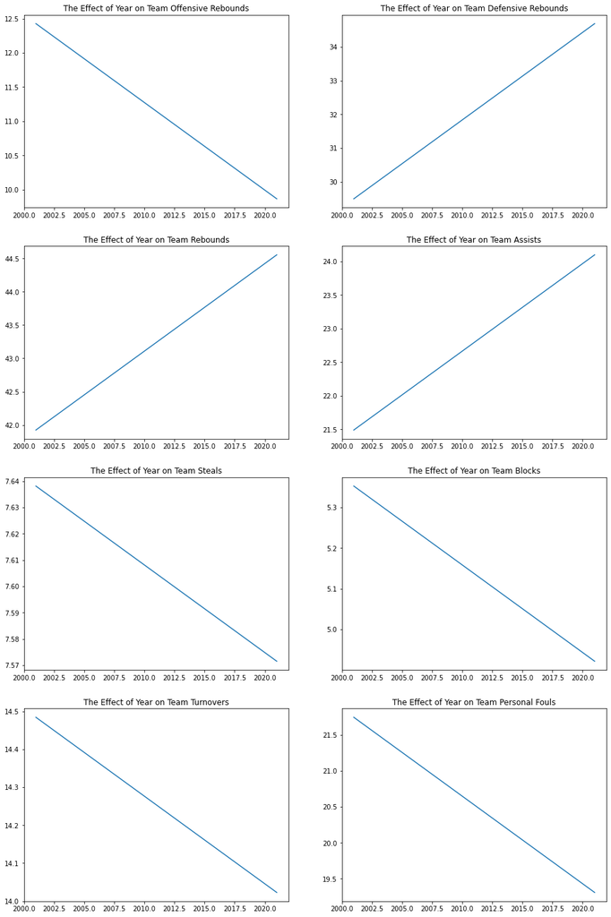

```python
fig, ax = plt.subplots(4, 2, figsize=(16,25))

x = games['YEAR']
y = pd.to_numeric(games['OREB_HOME'])  # Used OREB_HOME as arbitrary value, the AWAY value would work as well
m, b, r_value, p_value, std_err = stats.linregress(x,y)

ax[0, 0].plot(x, m*x + b)  # Plots regression line in subplot
ax[0, 0].title.set_text("The Effect of Year on Team Offensive Rebounds")
print("The Pearson correlation coefficient of OREB_HOME is", r_value)

y = pd.to_numeric(games['DREB_HOME'])
m, b, r_value, p_value, std_err = stats.linregress(x,y)

ax[0, 1].plot(x, m*x + b)
ax[0, 1].title.set_text("The Effect of Year on Team Defensive Rebounds")
print("The Pearson correlation coefficient of DREB_HOME is", r_value)

y = pd.to_numeric(games['REB_HOME'])
m, b, r_value, p_value, std_err = stats.linregress(x,y)

ax[1, 0].plot(x, m*x + b)
ax[1, 0].title.set_text("The Effect of Year on Team Rebounds")
print("The Pearson correlation coefficient of REB_HOME is", r_value)

y = pd.to_numeric(games['AST_HOME'])
m, b, r_value, p_value, std_err = stats.linregress(x,y)

ax[1, 1].plot(x, m*x + b)
ax[1, 1].title.set_text("The Effect of Year on Team Assists")
print("The Pearson correlation coefficient of AST_HOME is", r_value)

y = pd.to_numeric(games['STL_HOME'])
m, b, r_value, p_value, std_err = stats.linregress(x,y)

ax[2, 0].plot(x, m*x + b)
ax[2, 0].title.set_text("The Effect of Year on Team Steals")
print("The Pearson correlation coefficient of STL_HOME is", r_value)

y = pd.to_numeric(games['BLK_HOME'])
m, b, r_value, p_value, std_err = stats.linregress(x,y)

ax[2, 1].plot(x, m*x + b)
ax[2, 1].title.set_text("The Effect of Year on Team Blocks")
print("The Pearson correlation coefficient of BLK_HOME is", r_value)

y = pd.to_numeric(games['TOV_HOME'])
m, b, r_value, p_value, std_err = stats.linregress(x,y)

ax[3, 0].plot(x, m*x + b)
ax[3, 0].title.set_text("The Effect of Year on Team Turnovers")
print("The Pearson correlation coefficient of TOV_HOME is", r_value)

y = pd.to_numeric(games['PF_HOME'])
m, b, r_value, p_value, std_err = stats.linregress(x,y)

ax[3, 1].plot(x, m*x + b)
ax[3, 1].title.set_text("The Effect of Year on Team Personal Fouls")
print("The Pearson correlation coefficient of PF_HOME is", r_value)
```

To determine how significant the results are, I used the Pearson's Coefficient r and the link https://www.andrews.edu/~calkins/math/edrm611/edrm05.htm, which describes ranges of r in how well they correlate. The source states that correlation coefficients whose magnitude is less than 0.3 have little if any linear correlation. Since all the values of r that I found are less than 0.3, I decide that there is not a significant linear correlation between year and the game statistics and therefore an interaction term is not required. This link was helpful in going in-depth about the classification based on r if you would like to learn more.

Because I want to run a logistic regression on the data, I thought it would be interesting to visualize a logistic plot of the data to get a glance at how well the data will be correlated. To help visualize the data, I graphed the plot in red if the correlation coefficient is negative and in blue if positive.

```
[Text(0.5, 1.0, 'Personal Foul Differences vs Win/Loss Probability')]
```

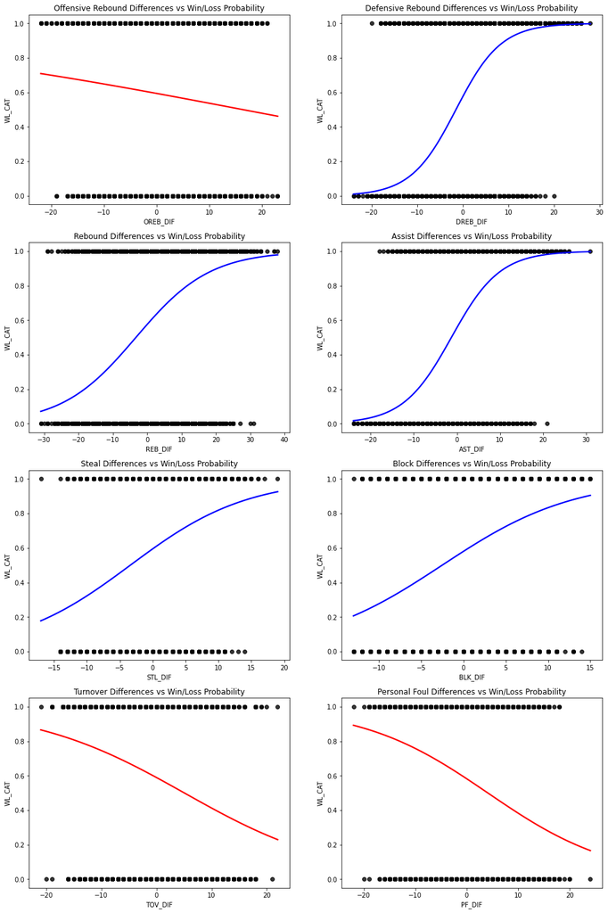

```python
fig, axes = plt.subplots(4, 2, figsize=(16,25))  # Creates subplot to make plots more aesthetic

sns.regplot(x=games['OREB_DIF'], y=games['WL_CAT'], data=games, logistic=True, ax=axes[0,0], ci=None,
            scatter_kws={'color': 'black'}, line_kws={'color': 'red'}).set(title='Offensive Rebound Differences vs Win/Loss Probability')
sns.regplot(x=games['DREB_DIF'], y=games['WL_CAT'], data=games, logistic=True, ax=axes[0,1], ci=None,
            scatter_kws={'color': 'black'}, line_kws={'color': 'blue'}).set(title='Defensive Rebound Differences vs Win/Loss Probability')
sns.regplot(x=games['REB_DIF'], y=games['WL_CAT'], data=games, logistic=True, ax=axes[1,0], ci=None,
            scatter_kws={'color': 'black'}, line_kws={'color': 'blue'}).set(title='Rebound Differences vs Win/Loss Probability')
sns.regplot(x=games['AST_DIF'], y=games['WL_CAT'], data=games, logistic=True, ax=axes[1,1], ci=None,
            scatter_kws={'color': 'black'}, line_kws={'color': 'blue'}).set(title='Assist Differences vs Win/Loss Probability')
sns.regplot(x=games['STL_DIF'], y=games['WL_CAT'], data=games, logistic=True, ax=axes[2,0], ci=None,
            scatter_kws={'color': 'black'}, line_kws={'color': 'blue'}).set(title='Steal Differences vs Win/Loss Probability')
sns.regplot(x=games['BLK_DIF'], y=games['WL_CAT'], data=games, logistic=True, ax=axes[2,1], ci=None,
            scatter_kws={'color': 'black'}, line_kws={'color': 'blue'}).set(title='Block Differences vs Win/Loss Probability')
sns.regplot(x=games['TOV_DIF'], y=games['WL_CAT'], data=games, logistic=True, ax=axes[3,0], ci=None,
            scatter_kws={'color': 'black'}, line_kws={'color': 'red'}).set(title='Turnover Differences vs Win/Loss Probability')
sns.regplot(x=games['PF_DIF'], y=games['WL_CAT'], data=games, logistic=True, ax=axes[3,1], ci=None, scatter_kws={'color': 'black'}, line_kws={'color': 'red'}).set(title='Personal Foul Differences vs Win/Loss Probability')
```

A cursory glance at the plots suggests that the strongest correlation coefficients are the graphs with defensive rebounds and assists. Additionally, it surprised me to see a negative correlation between offensive rebounds and win/loss probability.

### Hypothesis Testing

The null hypothesis is that each of the game statistics is independent in determining whether a team wins a game. To test this out, I used the logistic regression function from statsmodels with one independent variable at a time. I chose to do one independent variable at a time over using all independent variables together because 'REB_DIF' = 'OREB_DIF' + 'DREB_DIF'. Because of this, the columns will not all be independent of each other and as a result, if I were to run the model with all variables together, the p-value for these three rebounding variables will all be 1.00. I chose to fit the model with maximum likelihood, which is the default, but there are other fit functions that have their own advantages. If you want to learn more, take a look at https://www.statsmodels.org/dev/generated/statsmodels.discrete.discrete_model.Logit.html.

```python
cols = ['OREB_DIF','DREB_DIF','REB_DIF','AST_DIF','STL_DIF','BLK_DIF','TOV_DIF','PF_DIF']
coefs = []
for col in cols:
    logit_model = sm.Logit(games['WL_CAT'], games[col])  # Runs logistic regression for each independent variable
    result = logit_model.fit()
    print("coefficient:", result.params)
    coefs.append(result.params[0])
    print("p-value:",result.pvalues[0])
```

```
Optimization terminated successfully.
         Current function value: 0.691826
         Iterations 3
coefficient: OREB_DIF   -0.018478
dtype: float64
p-value: 1.961139034915039e-15
Optimization terminated successfully.
         Current function value: 0.535281
         Iterations 6
coefficient: DREB_DIF    0.20469
dtype: float64
p-value: 0.0
Optimization terminated successfully.
         Current function value: 0.618611
         Iterations 5
coefficient: REB_DIF    0.095593
dtype: float64
p-value: 0.0
Optimization terminated successfully.
         Current function value: 0.562060
         Iterations 6
coefficient: AST_DIF    0.182624
dtype: float64
p-value: 0.0
Optimization terminated successfully.
         Current function value: 0.671458
         Iterations 4
coefficient: STL_DIF    0.110085
dtype: float64
p-value: 4.842811207955203e-214
Optimization terminated successfully.
         Current function value: 0.665148
         Iterations 4
coefficient: BLK_DIF    0.138448
dtype: float64
p-value: 2.5135944465726838e-270
Optimization terminated successfully.
         Current function value: 0.676871
         Iterations 4
coefficient: TOV_DIF   -0.073326
dtype: float64
p-value: 7.922811092889145e-164
Optimization terminated successfully.
         Current function value: 0.669036
         Iterations 4
coefficient: PF_DIF   -0.087172
dtype: float64
p-value: 3.074544308181051e-236
```

To visualize my results from the model, I used a bar graph with the height being the absolute value of each game statistic's logistic regression coefficient. I used absolute value because I wanted to determine the largest effect overall. Minimizing a negatively correlated game statistic would be equivalent to maximizing a positively correlated game statistic.

[figure not shown]

```python
coefsA = [abs(c) for c in coefs]  # coefsA = abs(coefs)

fig = plt.figure(figsize=(10,12))
ax = fig.add_axes([0,0,1,1])

ax.bar(cols, coefsA, color=('r','b','b','b','b','r','r'))  # Blue = positive correlation, red = negative correlation
plt.title("Absolute Value of Logistic Regression Coefficients of Different Game Statistics")
plt.show()
```

### Conclusion

As you can see in the hypothesis testing section, the p-values in the logistic regression model are very small and all less than 0.05. Therefore, I can reject the null hypothesis that the game statistics are independent in determining whether a team wins a game.